# Cells in Jupyter

This one of the Maxwell's Equations $\eqref{eq:Maxwell_1}$ (IGNORE THIS LINE IF YOU JUST STARTED)

```python
Click on me. Then type "ESC" first, and "m" after. I will turn into a Markdown cell for you to write normal text
```

Click on me. Then type "ESC" first, and "y" after. I will turn into a code cell for you to write/execute your code

If you don't like neither of the above, do the same as above and type "r". I will be neutral.

# Text formatting

- Normal text: `hello world` only produces: hello world
- Italic: `_hello world_` or `*hello world*` will result in *hello world*
- Bold: `__hello world__` or `**hello world**` will result in **hello world**
- Strike-through: `~~hello world~~` will result in hello world
- Code-like looking: `` `f = my_function(a,b)` `` will result in `f = my_function(a,b)`
- Coloured text: `<span style="color:red">hello world</span>` will result in hello world
- Blockquotes

> Blockquotes are very handy in email to emulate reply text. This line is part of the same quote.

```
Quote break.
```

> This is a very long line that will still be quoted properly when it wraps. Oh boy let's keep writing to make sure this is long enough to actually wrap for everyone. Oh, you can *put* **Markdown** into a blockquote.
- Headings: These can be added by simply adding `#` at the front. For example

```
# hello world 1
## hello world 2
### hello world 3
#### hello world 4
##### hello world 5
```

will produce

# hello world 1

## hello world 2

### hello world 3

#### hello world 4

##### hello world 5

**OPTIONAL** For extra formatting

Headings and paragraphs can be added as standard HTML objects using tags. Then, they can be formatted via their standard arguments.

For example, for differen heading we would do

```
<h1 style="color:green" align="center">hello world 1</h1>
<h2 style="color:green" align="center">hello world 2</h2>
<h3 style="color:green" align="center">hello world 3</h3>
<h4 style="color:green" align="center">hello world 4</h4>
<h5 style="color:green" align="center">hello world 5</h5>
<h6 style="color:green" align="center">hello world 6</h6>
```

To produce respectively

[figure not shown]

See [this](https://www.w3schools.com/tags/att_hn_align.asp) to check the HTML documentation, for further info about heading arguments for style.

# Tables

Tables is another thing that is done differently in Jupyter.

In LaTeX you would usually do

> ```
> \begin{center}
> \begin{tabular}{ l c r }
>  cell1 & cell2 & cell3 \\
>  cell4 & cell5 & cell6 \\
>  cell7 & cell8 & cell9
> \end{tabular}
> \end{center}
> ```

Expecting something like

[figure not shown]

BUT, with Markdown we do

```
| Tables        | Are             |  Cool  |
| ------------- |:---------------:|-------:|
| col 3 is      | *right-aligned* | \$1600 |
| col 2 is      | ~~centered~~    |   \$12 |
| zebra stripes | are neat        |    \$1 |
```

where the position of colons (`:`) set the alignment.

to get this

| Tables | Are | Cool |
| --- | --- | --- |
| col 3 is | *right-aligned* | \$1600 |
| col 2 is | centered | \$12 |
| zebra stripes | are neat | \$1 |

However, this curretly just dosen't work in Jupyter. See known issues.

**KNOWN ISSUES**

- [Markdown table alignment stopped working](https://github.com/jupyter/notebook/issues/3919). So, all cell content is right-justified only. This [seems](https://stackoverflow.com/questions/21892570/ipython-notebook-align-table-to-the-left-of-cell#comment93038394_24638416) to be fixed in Jupyter lab though.

# Adding Equations

How to add equations

There are fundamentally two ways to add equations.

**Method A** Turn a cell into a Markdown cell and simply copy and paste your code as in LaTex. For example, let's write *Maxwell's equations*

> ```
> \begin{aligned}
> \nabla \times \vec{\mathbf{B}} -\, \frac1c\, \frac{\partial\vec{\mathbf{E}}}{\partial t} & = \frac{4\pi}{c}\vec{\mathbf{j}} \\
> \nabla \cdot \vec{\mathbf{E}} & = 4 \pi \rho \\
> \nabla \times \vec{\mathbf{E}}\, +\, \frac1c\, \frac{\partial\vec{\mathbf{B}}}{\partial t} & = \vec{\mathbf{0}} \\
> \nabla \cdot \vec{\mathbf{B}} & = 0
> \end{aligned}
> ```

If we copy and paste the above into a Markdown cell, and press Crtl+ENTER, then we get

\begin{aligned} \nabla \times \vec{\mathbf{B}} -\, \frac1c\, \frac{\partial\vec{\mathbf{E}}}{\partial t} & = \frac{4\pi}{c}\vec{\mathbf{j}} \\ \nabla \cdot \vec{\mathbf{E}} & = 4 \pi \rho \\ \nabla \times \vec{\mathbf{E}}\, +\, \frac1c\, \frac{\partial\vec{\mathbf{B}}}{\partial t} & = \vec{\mathbf{0}} \\ \nabla \cdot \vec{\mathbf{B}} & = 0 \label{hello} \end{aligned}

Inline equations can be added to Markdown cells like in LaTex.

For example, say we want to inser this inline equation `$c = \sqrt{a^2 + b^2}$`

```
This is my equation `$c = \sqrt{a^2 + b^2}$`
```

This is my equation $c = \sqrt{a^2 + b^2}$

TO-DO: Add further instructions or reference to doc on how to add equations

# Itemising

Suppose we want to write a lists of elements. In LaTeX, we would usually do:

> ```
> \begin{itemize}
>     \item My First item
>     \item My Second item
>     \item My Third item
> \end{itemize}
> ```

Unfortunately, if we tried the two methods shown above, this will fail. Instead, we will get somehting ugly as shown below.

\begin{itemize} \item My First item \item My Second item \item My Third item \end{itemize}

```python
%%latex
\begin{itemize}
    \item My First item
    \item My Second item
    \item My Third item
\end{itemize}
```

\begin{itemize} \item My First item \item My Second item \item My Third item \end{itemize}

**Markdown method** In Markdown, we need to do instead

> ```
> * My First item
> * My Second item
> * My Third item
> ```

If you copy and paste the lines above in a Markdown cell, then you get

- My First item
- My Second item
- My Third item

Similarly, we can do something similar when enumerating items. *Example*:

1. My First item
2. My Second item
3. My Third item

Further indexing

> ```
> * My First item
>     * hi
>         * hi again
>             * hi again and again
> * My Second item
> * My Third item
> ```

> this produces
- My First item
  - hi
    - hi again
      - hi again and again
- My Second item
- My Third item

# Adding media

## Let's add some pics

Let's say, you have an image in your computer (local system) or you want to display an image from your GitHub repository, or simply an image from the internet.

In Jupyter, Markdown cells allow you to do all of that in a very simple way.

**Method A** : Using an HTML image tag

Say, you have an image in your path `images/my_cool_image.png`. Just copy and paste the following lines, specifying the path to your image file. The arguments `width` and `height` are self-explanatory and OPTIONAL.

```
<img width="560" height="315" src="images/my_cool_image.png">
```

Then, we have

[figure not shown]

**Method B** : Using a Markdown tag

```
markdown
![](images/my_cool_image.png)
```

Then, you get

[figure not shown]

**KNOWN ISSUES**

However, block attributes to resize images with Markdown are not supported by jupyter's markdown renderer. So, this Markdown command will simply not work.

```
markdown
![](images/my_cool_image.png){:width="560px" height="315px"}
```

**Method C** Using `IPython` display

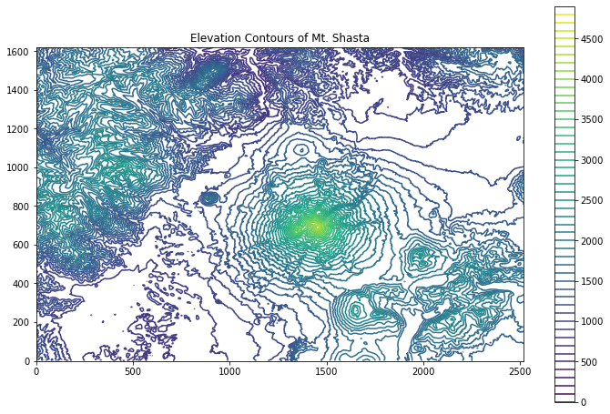

```python
from IPython.display import Image
Image("images/my_cool_image.png", width=560, height=315)
```

**MISCELLANEOUS** : Embed images from the web

Adding images from the internet or a github repository.

*For example*, the URL for the image above is

https://www.earthdatascience.org/images/tutorials/python/2016-07-26-visualize-digital-elevation-model-contours-matplotlib/2016-07-26-visualize-digital-elevation-model-contours-matplotlib_8_0.png

Then, if I use an either an HTML or Markdown tag, you only need to pass the URL instead of a local path

```
markdown
<img width="460" height="215" src="https://www.earthdatascience.org/images/tutorials/python/2016-07-26-visualize-digital-elevation-model-contours-matplotlib/2016-07-26-visualize-digital-elevation-model-contours-matplotlib_8_0.png">
```

Then, you get the same figure

[figure not shown]

Or even from a `GitHub` repository.

*For example*, the image with the link: https://raw.githubusercontent.com/broncio123/face_recognition/master/tests/test_images/obama.jpg

```
<img width="460" height="215" src="https://raw.githubusercontent.com/broncio123/face_recognition/master/tests/test_images/obama.jpg">
```

Then, we get

[figure not shown]

## Now more media

Similarly, this goes to videos in your PC and YouTube videos

### Adding a local video

**Method A** Using cell magic

HTML

```python
%%html
<video width="420" height="300" controls>
  <source src="images/my_cool_video.mp4" type="video/mp4">
</video>
```

[video not shown]

if you want to centre it

```python
%%html
<div align="middle">
<video width="420" height="300" controls>
      <source src="images/my_cool_video.mp4" type="video/mp4">
</video></div>
```

[video not shown]

**Method B** Using `IPython` display

Using an `HTML` tag

```python
from IPython.display import HTML

HTML("""
    <video width="420" height="300" controls>
        <source src="images/my_cool_video.mp4" type="video/mp4">
    </video>
""")
```

[video not shown]

Using a direct the direct command `Video`

```python
from IPython.display import Video

Video("images/my_cool_video.mp4", width=420, height=300)
```

[video not shown]

Non-copyright video taken from https://www.pexels.com/videos/

### Adding an online video

However, for YouTube videos they can't be directly embedded using HTML tags.

*For example*: In HTML to embed a vide you just provide the URL as below

```
<iframe width="420" height="300" src="https://www.youtube.com/embed/9bZkp7q19f0" frameborder="0" allowfullscreen></iframe>
```

In Markdown, copying and pasting this into a cell *just doesn't work!*

Instead you can try the following methods.

**Method A** Embed the link to the video in an image.

Then, copy and paste into a Markdown cell, an HTML tag like the one below.

```
<a href="http://www.youtube.com/watch?feature=player_embedded&v=YOUTUBE_VIDEO_ID_HERE
" target="_blank"><img src="http://img.youtube.com/vi/YOUTUBE_VIDEO_ID_HERE/0.jpg"
alt="IMAGE ALT TEXT HERE" width="420" height="300" border="10" /></a>
```

For example, for a YouTube video with link https://www.youtube.com/watch?v=9bZkp7q19f0 We do

```
<a href="http://www.youtube.com/watch?feature=player_embedded&v=9bZkp7q19f0
" target="_blank"><img src="http://img.youtube.com/vi/9bZkp7q19f0/0.jpg"
alt="Hello" width="420" height="300" border="10" /></a>
```

where the `YOUTUBE_VIDEO_ID` here is simply the last part of the link: `9bZkp7q19f0`. And as the image, we just take the first frame of the video (`0`)

Copy, paste, and then press ENTER, as usual, to get something like the stuff below.

[figure not shown]

Alternative

```
markdown
[![IMAGE ALT TEXT HERE](http://img.youtube.com/vi/9bZkp7q19f0/0.jpg)](http://www.youtube.com/watch?v=9bZkp7q19f0)
```

Then, you get

[figure not shown]

**Method B** Use `IPython` display in a code cell. See example below.

```python
from IPython.display import HTML
# Youtube
HTML('<iframe width="420" height="300" src="https://www.youtube.com/embed/9bZkp7q19f0" frameborder="0" allowfullscreen></iframe>')
```

[video not shown]

# Links

Adding *links* is very easy

> ```
> markdown
> [Click me!](https://www.google.com)
> [Put the mouse cursors over me, wait, and click me!](https://www.google.com "Google's Homepage ;)")
> ```

will produce

[Click me!](https://www.google.com)

[Put mouse cursors over me, wait, and click me!](https://www.google.com)

# Hyperlinks

Click here to jump to the beggining of this notebook.

This is the example of a hyperlink between two cells that are cross-referenced.

**First**, we define a "*label*" to the cell we want to reference, as we did with the first cell of this notebook, done as shown below.

```
<a id='hello_cell'></a>
# Hello world
```

**Second**, we define a "*reference*" to that cell using the following syntax.

```
Click [here](#hello_cell) to jump to the beggining of this notebook.
```

**NOTE**: In LaTeX this the equivalent to doing

```
% Somewhere in the .tex document
\section{This is a section}
\label{sec:sec1}
```

$\vdots$

```
% Somewhere else in the LaTex document
Clikck here \ref{sec:sec1} to jump to the section in the PDF.
```

# Equation numbering/referencing

NOTE 1: This is currently possible using the `MathJax Equation Numbering`. This can be installed according to instructions provided [here](https://stackoverflow.com/questions/41241984/equation-numbering-in-jupyter-notebooks/42940005#42940005).

A working example is shown next.

**First** Say we want to number this equation

```
\begin{equation}
\nabla \times \vec{\mathbf{B}} -\, \frac1c\, \frac{\partial\vec{\mathbf{E}}}{\partial t} = \frac{4\pi}{c}\vec{\mathbf{j}}
\end{equation}
```

That produces this output

\begin{equation} \nabla \times \vec{\mathbf{B}} -\, \frac1c\, \frac{\partial\vec{\mathbf{E}}}{\partial t} = \frac{4\pi}{c}\vec{\mathbf{j}} \label{eq:Maxwell_1} \end{equation}

In *Markdown* is not different. We can label equations like in *LaTeX*. So, we just add a label, like `\label{eq:Maxwell_1}`

```
\begin{equation}
\nabla \times \vec{\mathbf{B}} -\, \frac1c\, \frac{\partial\vec{\mathbf{E}}}{\partial t} = \frac{4\pi}{c}\vec{\mathbf{j}}
\label{eq:Maxwell_1}
\end{equation}
```

**Second** Now, suppose that you want to reference this equation in your text

In LaTeX, to reference the equation normally we do:

> Hey! Look at this pretty equation `\ref{eq:Maxwell_1}`

BUT, in Markdown we actually do:

> Hey! Look at this pretty equation `$\eqref{eq:Maxwell_1}$`

which procudes a hyperlink to the referenced equation.

> Hey! Look at this pretty equation $\eqref{eq:Maxwell_1}$

NOTE 2: Every now and then when adding more equations and rendering hyperlinks to equations you will find something like `(???)`. To fix this, just click on the icon

[figure not shown]

This will renumber all equations consistently

NOTE 3: This doesn't seem to work with other equation environments, such as

```
\begin{align}
.
.
.
\end{align}
```

# Link to other NBs and files

Click me to see something cool.

This is an example of a link to a Jupyter Notebook, called `MockNotebook.ipynb`, which is automatically launched on your browser after clicking.

The syntax to add a link to a notebook is not any diffent.

> ```
> [Click me](images/MockNotebook.ipynb) to see something cool.
> ```

Similarly, for other files.

> ```
> [Click me](images/my_cool_image.png) to see something cool.
> ```

Click me to see a cool picture.

# Adding a Bibliography

## **Method X** Using HTML attributes

**FIRST** Convert `.bib` file into a formated `.html` file using [`nbconvert`](https://github.com/jupyter/nbconvert-examples).

This approach allows us to insert citations in Markdown cells using HTML data attributes.

Installation instructions for `nbconverter` can be found [here](https://nbconvert.readthedocs.io/en/latest/install.html). This can be easily installed with `conda` though, a number of dependencies need to be considered. See instructions.

*Example*: We want to turn a file like [this](https://github.com/broncio123/riemann_book/blob/master/riemann.bib) into something like [this](https://github.com/broncio123/riemann_book/blob/master/riemann_bib.html)

For instance, a `bib` entry

```
@article{greenberg1997analysis,
  title={Analysis and approximation of conservation laws with source terms},
  author={Greenberg, JM and Leroux, AY and Baraille, R and Noussair, A},
  journal={SIAM Journal on Numerical Analysis},
  volume={34},
  number={5},
  pages={1980--2007},
  year={1997},
  publisher={SIAM}
}
```

is turned into an `html` object like this

```
<a name="greenberg1997analysis"></a><pre>
@article{<a href="riemann.html#greenberg1997analysis">greenberg1997analysis</a>,
  title = {Analysis and approximation of conservation laws with source terms},
  author = {Greenberg, JM and Leroux, AY and Baraille, R and Noussair, A},
  journal = {SIAM Journal on Numerical Analysis},
  volume = {34},
  number = {5},
  pages = {1980--2007},
  year = {1997},
  publisher = {SIAM}
}
</pre>
```

within an HTML file.

**SECOND**

In *LaTeX* for your `.bib` file to be loaded and being able to insert citations, at the end of your doc you usually have to do speciy a bibliography style and the path of your `.bib` file

```
\bibliographystyle{siam}
\bibliography{my_bib}
```

Checking how this works ...

https://github.com/jupyter/nbconvert-examples/tree/master/citations

https://github.com/broncio123/riemann_book/tree/master/files_for_latex_pdf

[figure not shown]

**THIRD** Add inline citation.

In LaTeX we would do

> ```
> This is a cool paper: Ref \cite{greenberg1997analysis}
> ```

In a Markdown cell in Jupyter, we do

> ```
> markdown
> This is a cool paper: Ref <cite data-cite="greenberg1997analysis">(Greenberg, 1997)</cite>
> ```

**NOTE**

An old project called BibTeX2HTML aimed to do something like this (Last commit: almost 5 years ago!).

HOW TO REMOVE REDUNDANCIES IN BIB FILES? In the case different people have citations to same ref.

## **Method Y**: Using `jekyll-scholar` (Jupyter Book)

If using the [`Jupter Book`](https://jupyterbook.org/intro.html) project as a template, we just need to modify the `.bib` file of the project. Then, for *in-line* citations, we do.

> Hello world! This is a citation `{% cite holdgraf_evidence_2014 %}`.

To generate a bibliography or a list of cited references at the end of a notebook, we just add in a cell

```
{% bibliography --cited %}
```

to show the full list of references in the `.bib` file, we do instead

```
{% bibliography %}
```

Check this notebook to see how it is done in a notebook and for a further explanation. This was directly [downloaded](https://jupyterbook.org/features/citations.html) from the Jupyter Book project.

**NOTE**

The bibliography will be only visible for a rendered HTML from the book. Check [this](https://jupyterbook.org/features/citations.html) documentation for a further explanation.

**KNOWN ISSUES**

(From the developers) These are features that we are playing around with, but might change in how they behave or are controlled. Note that they behave a bit unstable!

## Method Z: Jupyter extension (LaTeX_envs )

This uses [this](https://jupyter-contrib-nbextensions.readthedocs.io/en/latest/nbextensions/latex_envs/README.html#) Jupyter extension `LaTeX_envs`. It can be enabled from extension manager.

- Accetps `\cite{}` and `\ref{}`
- Provides auto-completion
- For bibliography only specify `.bib` file path (ISSUE)
- Adds References section automatically at the end of notebook

See this document for an example

**KNOWN ISSUES**

Path to `.bib` file not recognised **?**

Bibliography list not rendered.

# References

- [Markdown cheatsheet](https://github.com/adam-p/markdown-here/wiki/Markdown-Cheatsheet)
- [Jupyter Notebook documentation: Motivating Examples](https://jupyter-notebook.readthedocs.io/en/stable/examples/Notebook/Typesetting%20Equations.html#)
- [Numbering Equations in Jupyter](https://stackoverflow.com/questions/41241984/equation-numbering-in-jupyter-notebooks/42940005#42940005)
- [Tips and Tricks](https://www.dataquest.io/blog/jupyter-notebook-tips-tricks-shortcuts/)
- [Books with Jupyter](https://jupyterbook.org/intro.html)

# Turning GitHub repo into a website

[figure not shown]

Overview:

Instructions for Mac

- Install `jekyll`

  > `sudo gem install jekyll`

```python
from IPython.display import HTML
# Youtube
HTML('<iframe width="420" height="300" src="https://www.youtube.com/embed/nN6QuNqmAwk" frameborder="0" allowfullscreen></iframe>')
```

[video not shown]

`gem` The software package is called a “gem” which contains a packaged Ruby application or library.